# Project: Identify Customer Segments

In this project, you will apply unsupervised learning techniques to identify segments of the population that form the core customer base for a mail-order sales company in Germany. These segments can then be used to direct marketing campaigns towards audiences that will have the highest expected rate of returns. The data that you will use has been provided by our partners at Bertelsmann Arvato Analytics, and represents a real-life data science task.

This notebook will help you complete this task by providing a framework within which you will perform your analysis steps. In each step of the project, you will see some text describing the subtask that you will perform, followed by one or more code cells for you to complete your work. **Feel free to add additional code and markdown cells as you go along so that you can explore everything in precise chunks.** The code cells provided in the base template will outline only the major tasks, and will usually not be enough to cover all of the minor tasks that comprise it.

It should be noted that while there will be precise guidelines on how you should handle certain tasks in the project, there will also be places where an exact specification is not provided. **There will be times in the project where you will need to make and justify your own decisions on how to treat the data.** These are places where there may not be only one way to handle the data. In real-life tasks, there may be many valid ways to approach an analysis task. One of the most important things you can do is clearly document your approach so that other scientists can understand the decisions you've made.

At the end of most sections, there will be a Markdown cell labeled **Discussion**. In these cells, you will report your findings for the completed section, as well as document the decisions that you made in your approach to each subtask. **Your project will be evaluated not just on the code used to complete the tasks outlined, but also your communication about your observations and conclusions at each stage.**

```python
# import libraries here; add more as necessary
import numpy as np
import pandas as pd
import matplotlib.pyplot as plt
import seaborn as sns
from ast import literal_eval
from sklearn.preprocessing import Imputer, StandardScaler
from sklearn.decomposition import PCA
from sklearn.cluster import KMeans
import torch

# magic word for producing visualizations in notebook
%matplotlib inline
```

### Step 0: Load the Data

Each row of the demographics files represents a single person, but also includes information outside of individuals, including information about their household, building, and neighborhood. You will use this information to cluster the general population into groups with similar demographic properties. Then, you will see how the people in the customers dataset fit into those created clusters. The hope here is that certain clusters are over-represented in the customers data, as compared to the general population; those over-represented clusters will be assumed to be part of the core userbase. This information can then be used for further applications, such as targeting for a marketing campaign.

To start off with, load in the demographics data for the general population into a pandas DataFrame, and do the same for the feature attributes summary. Note for all of the `.csv` data files in this project: they're semicolon (`;`) delimited, so you'll need an additional argument in your [`read_csv()`](https://pandas.pydata.org/pandas-docs/stable/generated/pandas.read_csv.html) call to read in the data properly. Also, considering the size of the main dataset, it may take some time for it to load completely.

Once the dataset is loaded, it's recommended that you take a little bit of time just browsing the general structure of the dataset and feature summary file. You'll be getting deep into the innards of the cleaning in the first major step of the project, so gaining some general familiarity can help you get your bearings.

```python
# Load in the feature summary file.
feat_info =  pd.read_csv("./AZDIAS_Feature_Summary_custom.csv", sep = ",")

# Load in the general demographics data.
azdias = pd.read_csv("./Udacity_AZDIAS_Subset.csv", sep = ";")
azdias.columns = feat_info["attribute_in_English"]
```

```python
# Check the structure of the data after it's loaded (e.g. print the number of
# rows and columns, print the first few rows).

print(azdias.shape)
print(azdias.head().iloc[:,:5])
```

```
(891221, 85)
attribute_in_English  Best-ager-typology  Age-estimate-name-analysis  Gender  \
0                                     -1                           2       1
1                                     -1                           1       2
2                                     -1                           3       2
3                                      2                           4       2
4                                     -1                           3       1

attribute_in_English  Preferred-info-buying-channels  \
0                                                2.0
1                                                5.0
2                                                3.0
3                                                2.0
4                                                5.0

attribute_in_English  Fin-typo-low-financial-interest
0                                                   3
1                                                   1
2                                                   1
3                                                   4
4                                                   4
```

```python
print(feat_info.shape)
print(feat_info.head())
```

```
(85, 5)
              attribute             attribute_in_English information_level  \
0              AGER_TYP               Best-ager-typology            person
1  ALTERSKATEGORIE_GROB       Age-estimate-name-analysis            person
2             ANREDE_KZ                           Gender            person
3         CJT_GESAMTTYP   Preferred-info-buying-channels            person
4     FINANZ_MINIMALIST  Fin-typo-low-financial-interest            person

          type missing_or_unknown
0  categorical             [-1,0]
1      ordinal           [-1,0,9]
2  categorical             [-1,0]
3  categorical                [0]
4      ordinal               [-1]
```

```python
print(azdias.info())
```

```
<class 'pandas.core.frame.DataFrame'>
RangeIndex: 891221 entries, 0 to 891220
Data columns (total 85 columns):
Best-ager-typology                   891221 non-null int64
Age-estimate-name-analysis           891221 non-null int64
Gender                               891221 non-null int64
Preferred-info-buying-channels       886367 non-null float64
Fin-typo-low-financial-interest      891221 non-null int64
Fin-typo-money-saver                 891221 non-null int64
Fin-typo-be-prepared                 891221 non-null int64
Fin-typo-investor                    891221 non-null int64
Fin-typo-inconspicuous               891221 non-null int64
Fin-typo-home ownership              891221 non-null int64
financial-type-description           891221 non-null int64
Year-of-birth                        891221 non-null int64
Vacation-habits                      886367 non-null float64
Mem-environ-sustain                  891221 non-null int64
Health-typology                      891221 non-null int64
Life-stage-fine-scale                886367 non-null float64
Life-stage-rough-scale               886367 non-null float64
Family-type-fine-scale               886367 non-null float64
Family-type-rough-scale              886367 non-null float64
Social-status-fine-scale             886367 non-null float64
Social-status-rough-scale            886367 non-null float64
Nationality-basis-name               891221 non-null int64
youth-dominating-movement            891221 non-null int64
return-type                          886367 non-null float64
persnlity-typo-socially-minded       891221 non-null int64
persnlity-typo-family-minded         891221 non-null int64
persnlity-typo-religious             891221 non-null int64
persnlity-typo-materialistic         891221 non-null int64
persnlity-typo-dreamful              891221 non-null int64
persnlity-typo-sensual-minded        891221 non-null int64
persnlity-typo-event-oriented        891221 non-null int64
persnlity-typo-cultural-minded       891221 non-null int64
persnlity-typo-rational              891221 non-null int64
persnlity-typo-critical-minded       891221 non-null int64
persnlity-typo-dominant-minded       891221 non-null int64
persnlity-typo-combative attitude    891221 non-null int64
persnlity-typo-dutiful               891221 non-null int64
```

[output cut: 36 more lines]

```
Neighborhood-typo                    770025 non-null float64
Num-cars-PLZ8-region                 785421 non-null float64
Num-1-2-family-houses-PLZ8           774706 non-null float64
Num-3-5-family-houses-PLZ8           774706 non-null float64
Num-6-10-family-houses-PLZ8          774706 non-null float64
Num-10p-family-houses-PLZ8           774706 non-null float64
Most-comm-build-type-PLZ8            774706 non-null float64
Num-households-within-PLZ8           774706 non-null float64
Num-buildings-within-PLZ8            774706 non-null float64
Share-of-unemployment-comm           794005 non-null float64
size-community                       794005 non-null float64
Share-of-unemploy-relative-county    794005 non-null float64
dtypes: float64(49), int64(32), object(4)
memory usage: 578.0+ MB
None
```

> **Tip**: Add additional cells to keep everything in reasonably-sized chunks! Keyboard shortcut `esc --> a` (press escape to enter command mode, then press the 'A' key) adds a new cell before the active cell, and `esc --> b` adds a new cell after the active cell. If you need to convert an active cell to a markdown cell, use `esc --> m` and to convert to a code cell, use `esc --> y`.

## Step 1: Preprocessing

### Step 1.1: Assess Missing Data

The feature summary file contains a summary of properties for each demographics data column. You will use this file to help you make cleaning decisions during this stage of the project. First of all, you should assess the demographics data in terms of missing data. Pay attention to the following points as you perform your analysis, and take notes on what you observe. Make sure that you fill in the **Discussion** cell with your findings and decisions at the end of each step that has one!

#### Step 1.1.1: Convert Missing Value Codes to NaNs

The fourth column of the feature attributes summary (loaded in above as `feat_info`) documents the codes from the data dictionary that indicate missing or unknown data. While the file encodes this as a list (e.g. `[-1,0]`), this will get read in as a string object. You'll need to do a little bit of parsing to make use of it to identify and clean the data. Convert data that matches a 'missing' or 'unknown' value code into a numpy NaN value. You might want to see how much data takes on a 'missing' or 'unknown' code, and how much data is naturally missing, as a point of interest.

**As one more reminder, you are encouraged to add additional cells to break up your analysis into manageable chunks.**

```python
# Identify missing or unknown data values and convert them to NaNs.

# How many blanks(naturally missing)in the dataset.
blank_count = np.sum(np.sum(azdias.isnull(), axis = 0), axis = 0)
print("Number of blanks(naturally missing data) across the dataset: {}".format(blank_count))

# Percentage of data that is blank
perc_natural_missing = blank_count/np.multiply(azdias.shape[0], azdias.shape[1])
print("Percentage of data in the dataset that is naturally missing: {:.2f}".format(perc_natural_missing * 100))
```

```
Number of blanks(naturally missing data) across the dataset: 4896838
Percentage of data in the dataset that is naturally missing: 6.46
```

```python
# How many missing/unknown code data in the dataset
feat_info["missing_or_unknown"] = feat_info["missing_or_unknown"].str.replace("X","'X'")
feat_info["missing_or_unknown"] = feat_info["missing_or_unknown"].str.replace("'X''X'","'XX'")
feat_info["missing_or_unknown"] = feat_info["missing_or_unknown"].apply(lambda x: literal_eval(x))
missing_or_unknown_lst = [i for i in  feat_info["missing_or_unknown"]]
dict_columns_missing_code = {i[0]:i[1] for i in zip(azdias.columns,missing_or_unknown_lst)}
missing_unknown_columnwise = np.sum(azdias.isin(dict_columns_missing_code),axis = 0)
tot_miss_unkn_values = np.sum(missing_unknown_columnwise, axis = 0)
print("Number of missing/unknown values across the dataset: {}".format(tot_miss_unkn_values))

# Percentage of data that is missing or unknown values
perc_miss_unkn_missing = tot_miss_unkn_values/np.multiply(azdias.shape[0], azdias.shape[1])
print("Percentage of data in the dataset that is missing/unknown: {:.2f}".format(perc_miss_unkn_missing * 100))
```

```
Number of missing/unknown values across the dataset: 3477091
Percentage of data in the dataset that is missing/unknown: 4.59
```

```python
# Setting the unknown and missing values to np.NaN
azdias.fillna(np.NaN, inplace=True) # this line is redundant
azdias[azdias.isin(dict_columns_missing_code)] = np.NaN
```

```python
#To confirm if everthing has gone well, How many blanks in this dataset.
blank_count_result = np.sum(np.sum(azdias.isnull(), axis = 0), axis = 0)
print("Number of blanks across the dataset now: {}".format(blank_count_result))

# Percentage of data that is blank now
perc_natural_missing_result = blank_count_result/np.multiply(azdias.shape[0], azdias.shape[1])
print("Percentage of data in the dataset that is blank now: {:.2f}".format(perc_natural_missing_result * 100))
```

```
Number of blanks across the dataset now: 8373929
Percentage of data in the dataset that is blank now: 11.05
```

#### Step 1.1.2: Assess Missing Data in Each Column

How much missing data is present in each column? There are a few columns that are outliers in terms of the proportion of values that are missing. You will want to use matplotlib's [`hist()`](https://matplotlib.org/api/_as_gen/matplotlib.pyplot.hist.html) function to visualize the distribution of missing value counts to find these columns. Identify and document these columns. While some of these columns might have justifications for keeping or re-encoding the data, for this project you should just remove them from the dataframe. (Feel free to make remarks about these outlier columns in the discussion, however!)

For the remaining features, are there any patterns in which columns have, or share, missing data?

```python
# Perform an assessment of how much missing data there is in each column of the dataset.

# Features classified as objects.
# print(azdias.columns[np.where(azdias.dtypes == "object")])
blanks_in_columns = np.sum(azdias.isnull(), axis = 0)
blanks_in_columns.sort_values(ascending = False, axis = 0, inplace = True)
print(blanks_in_columns)
```

```
attribute_in_English
Academic-title-flag                  889061
Best-ager-typology                   685843
Consumer-pattern-past-12-months      584612
Most-comm-build-type-microcell       476524
Year-of-birth                        392318
Birthdate-of-head-of-household       310267
Neighborhood-typo                    158064
purchasing-power-in-region           158064
Likelihood-of-children-household     147988
Num-10p-family-houses-microcell      133324
Num-buildings-within-microcell       133324
Movement-patterns                    133324
Num-1-2-family-houses-microcell      133324
Num-3-5-family-houses-microcell      133324
Num-6-10-family-houses-microcell     133324
Num-buildings-within-PLZ8            116515
Num-households-within-PLZ8           116515
Most-comm-build-type-PLZ8            116515
Num-10p-family-houses-PLZ8           116515
Num-1-2-family-houses-PLZ8           116515
Num-6-10-family-houses-PLZ8          116515
Num-3-5-family-houses-PLZ8           116515
Shopper-typology                     111196
Insurance-typology                   111196
Health-typology                      111196
Nationality-basis-name               108315
youth-dominating-movement            108164
Num-cars-PLZ8-region                 105800
Num-households-in-building            99611
Welth-life-stage-intl-code            99352
                                      ...
return-type                            4854
Online-affinity                        4854
Social-status-fine-scale               4854
Social-status-rough-scale              4854
Vacation-habits                        4854
Age-estimate-name-analysis             2881
financial-type-description                0
Mem-environ-sustain                       0
```

[output cut: 8 more lines]

```
persnlity-typo-socially-minded            0
persnlity-typo-religious                  0
persnlity-typo-materialistic              0
persnlity-typo-dreamful                   0
persnlity-typo-sensual-minded             0
persnlity-typo-event-oriented             0
persnlity-typo-cultural-minded            0
persnlity-typo-rational                   0
persnlity-typo-critical-minded            0
persnlity-typo-dominant-minded            0
persnlity-typo-combative attitude         0
persnlity-typo-dutiful                    0
persnlity-typo-tradional-minded           0
Energy-consumption-typology               0
Length: 85, dtype: int64
```

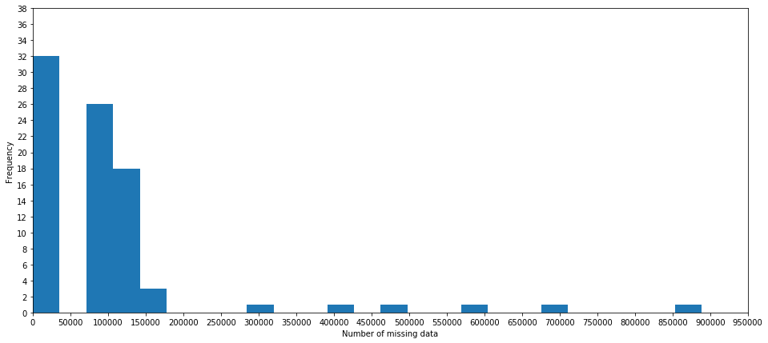

```python
fig = plt.figure(figsize=(16,7))
ax = fig.add_subplot(111)
ax.hist(blanks_in_columns, bins = 25)
ax.set_xlabel("Number of missing data")
ax.set_ylabel("Frequency")
ax.set_xlim(0,900000)
ax.set_xticks(np.arange(0, 1000000, 50000))
ax.set_ylim(0,35)
ax.set_yticks(np.arange(0,40,2))
```

```python
# Investigate patterns in the amount of missing data in each column.
azdias_ = azdias.fillna(-5) # filling -5 for all missing values for the ease of using it during groupby

def draw_missing_value_heatmap(df, feature_name, cmap):
    group = azdias_.groupby(feature_name).apply(lambda x: np.sum(x == -5)).drop(feature_name, axis = 1)
    df_heatmap = group.apply(lambda x: 100 * x/(x.sum()))
    df_heatmap = df_heatmap.loc[:,np.logical_not(df_heatmap.isnull().any())]
    fig = plt.figure(figsize=(15,4))
    ax = plt.gca()
    ax.set_title("Number of missing values for " + feature_name)
    sns.heatmap(df_heatmap,annot = False, linewidths=0.5, square = True, cmap = cmap)
```

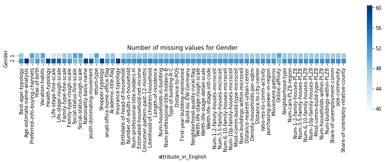

```python
feature = "Gender"
draw_missing_value_heatmap(azdias_, feature, "Blues")
```

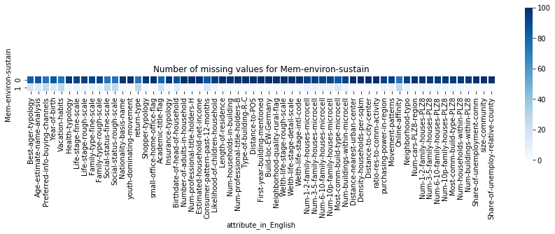

```python
feature = "Mem-environ-sustain"
draw_missing_value_heatmap(azdias_,feature, "Blues")
```

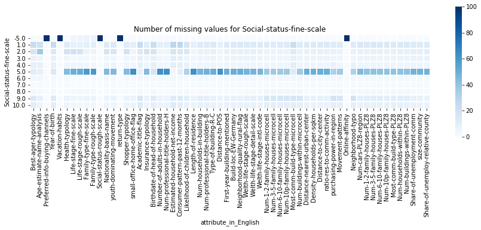

```python
feature = "Social-status-fine-scale"
draw_missing_value_heatmap(azdias_, feature, "Blues")
```

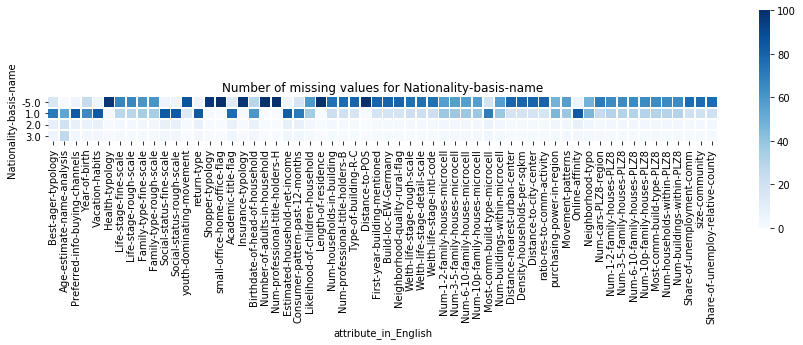

```python
feature = "Nationality-basis-name"
draw_missing_value_heatmap(azdias_, feature, "Blues")
```

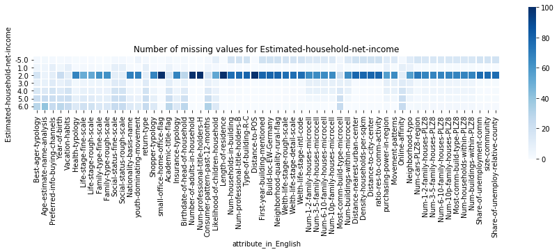

```python
feature = "Estimated-household-net-income"
draw_missing_value_heatmap(azdias_, feature, "Blues")
```

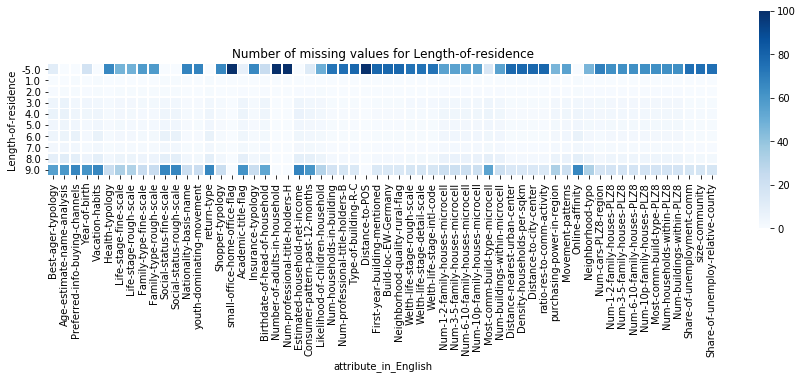

```python
feature = "Length-of-residence"
draw_missing_value_heatmap(azdias_, feature, "Blues")
```

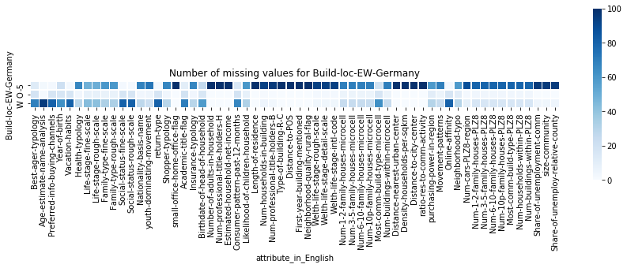

```python
feature = "Build-loc-EW-Germany"
draw_missing_value_heatmap(azdias_, feature, "Blues")
```

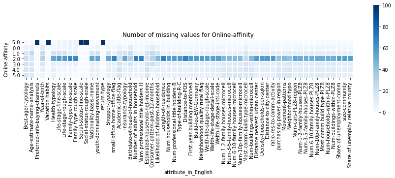

```python
feature = "Online-affinity"
draw_missing_value_heatmap(azdias_, feature, "Blues")
```

```python
del azdias_
```

```python
# Remove the outlier columns from the dataset. (You'll perform other data
# engineering tasks such as re-encoding and imputation later.)
#Assuming the missing values in each feature should also fall under Gaussian distribution albeit one heavily skewed to the right.
# 99.7% of all samples must be within  +/- 3(std deviation) from the mean else there are in the 0.03 percentile and could be
# considered as outliers.

Std_num_missing_values = np.std(blanks_in_columns)
Avg_num_missing_values = np.mean(blanks_in_columns)

# lower_limit is not applicable as number of missing values in any feature can't go below zero.
lower_limit = Avg_num_missing_values - (3 * Std_num_missing_values)
Upper_limit = Avg_num_missing_values + (3 * Std_num_missing_values)

outlier_index = blanks_in_columns[blanks_in_columns > Upper_limit].index
azdias.drop(labels = outlier_index, axis = 1, inplace=True)
print("The shape of the dataset after outlier columns are removed {}".format(azdias.shape))

azdias.drop("Type-of-building-R-C", axis = 1, inplace = True)
```

```
The shape of the dataset after outlier columns are removed (891221, 82)
```

#### Discussion 1.1.2: Assess Missing Data in Each Column

## Observations regarding missing data:

Note: All observations listed below has been gleaned from the heatmaps above. number "-5" in the heatmap means missing_unknown or naturally missing data. Also, i have converted all the columns names from German to English for the ease of my understanding. However in all discussion sections, i have presented my findings using German column names.

1) Women have more missing values than men. May be even in Germany, women socio-economic status is not on par with men yet or they take their privacy more seriously. 2) People those who are not part of any environmental sustainability movements in their youth tend to have more missing values. 3) High income earners tend to have more missing values. May be privacy is a big concern for these people, especially minimalistic high income earners. 4) German sounding names have more missing data. 5) If the length of residence is above 10 years they also seem to have more missing data. 6) People who lived in West germany tend to have more missing data. 7) People with middle level online affinity tend to have more missing values.

So, one assumption would be mostly high income earners tend to have more missing values when compared to other segments of the population. Also, they will have german sounding names and they would have mostly lived in the same residence for over 10 years as well as they would have lived in West Germany after world war and there infinity would be medium (code 2).

## Columns removed

I simply assumed Gaussian distribution on number of missing data on each column. The columns that fell outside "mean + 3(std.dev)" i removed from the dataset as 99.7% of all data will fall within "mean +/- 3(std.dev)". Columns outside is in the 3rd percentile and can be considered outliers.

I have removed the following columns - 1) TITEL_KZ 2) AGER_TYP and 3) KK_KUNDENTYP

I have also dropped the column "GEBAEUDETYP", because in the customer dataset(Udacity_CUSTOMERS_Subset.csv), for this column "GEBAEUDETYP" we dont have any data point for subcategory "5: company building w/o known company" and it is creating one less column for customer dataset while using the clean_data function.

#### Step 1.1.3: Assess Missing Data in Each Row

Now, you'll perform a similar assessment for the rows of the dataset. How much data is missing in each row? As with the columns, you should see some groups of points that have a very different numbers of missing values. Divide the data into two subsets: one for data points that are above some threshold for missing values, and a second subset for points below that threshold.

In order to know what to do with the outlier rows, we should see if the distribution of data values on columns that are not missing data (or are missing very little data) are similar or different between the two groups. Select at least five of these columns and compare the distribution of values.

- You can use seaborn's [`countplot()`](https://seaborn.pydata.org/generated/seaborn.countplot.html) function to create a bar chart of code frequencies and matplotlib's [`subplot()`](https://matplotlib.org/api/_as_gen/matplotlib.pyplot.subplot.html) function to put bar charts for the two subplots side by side.
- To reduce repeated code, you might want to write a function that can perform this comparison, taking as one of its arguments a column to be compared.

Depending on what you observe in your comparison, this will have implications on how you approach your conclusions later in the analysis. If the distributions of non-missing features look similar between the data with many missing values and the data with few or no missing values, then we could argue that simply dropping those points from the analysis won't present a major issue. On the other hand, if the data with many missing values looks very different from the data with few or no missing values, then we should make a note on those data as special. Make sure you report your observations in the discussion section. **Either way, you should continue your analysis below using just the subset of the data with few or no missing values.**

```python
# How much data is missing in each row of the dataset?
azdias["num_NaNs_in_row"] = np.sum(azdias.isnull(), axis = 1)
azdias.sort_values("num_NaNs_in_row", ascending = False, axis = 0).iloc[:10,80:]
```

| attribute_in_English | Share-of-unemploy-relative-county | num_NaNs_in_row |
| --- | --- | --- |
| 732775 | NaN | 50 |
| 643174 | NaN | 50 |
| 589814 | NaN | 49 |
| 121410 | NaN | 49 |
| 121451 | NaN | 49 |
| 634830 | NaN | 49 |
| 121446 | NaN | 49 |
| 634833 | NaN | 49 |
| 634838 | NaN | 49 |
| 634839 | NaN | 49 |

```python
# Write code to divide the data into two subsets based on the number of missing
# values in each row.
NaN_row_std_dev = np.std(azdias["num_NaNs_in_row"])
NaN_row_mean = np.mean(azdias["num_NaNs_in_row"])
NaN_row_threshold = NaN_row_mean + 2 * (NaN_row_std_dev)
print("The number of NaN values in a row that determines which subset a row belongs to: {}".format(NaN_row_threshold))
azdias["threshold_flag"] = azdias["num_NaNs_in_row"].apply(lambda x: 1 if x <= NaN_row_threshold else 2)
# threshold_flag 1 represents row with no or few missing values and threshold_flag 2 represents rows with lot of missing values
azdias.iloc[:15,80:]
```

```
The number of NaN values in a row that determines which subset a row belongs to: 33.834598217095376
```

| attribute_in_English | Share-of-unemploy-relative-county | num_NaNs_in_row | threshold_flag |
| --- | --- | --- | --- |
| 0 | NaN | 45 | 2 |
| 1 | 4.0 | 1 | 1 |
| 2 | 2.0 | 1 | 1 |
| 3 | 3.0 | 7 | 1 |
| 4 | 5.0 | 1 | 1 |
| 5 | 3.0 | 1 | 1 |
| 6 | 3.0 | 2 | 1 |
| 7 | 2.0 | 1 | 1 |
| 8 | 3.0 | 1 | 1 |
| 9 | 1.0 | 1 | 1 |
| 10 | 5.0 | 0 | 1 |
| 11 | NaN | 49 | 2 |
| 12 | 4.0 | 8 | 1 |
| 13 | 4.0 | 9 | 1 |
| 14 | NaN | 49 | 2 |

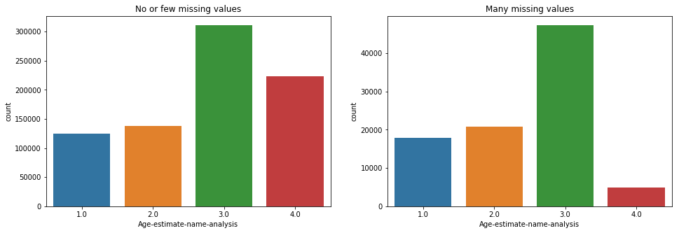

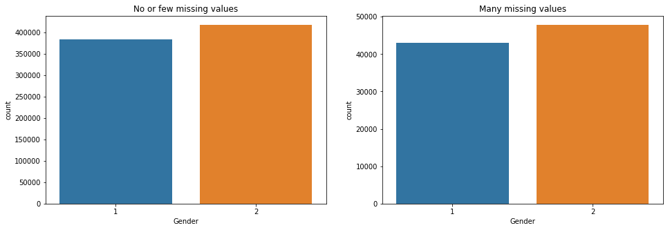

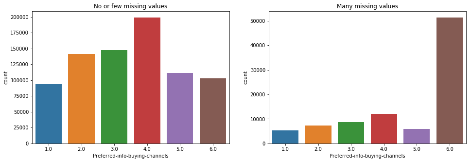

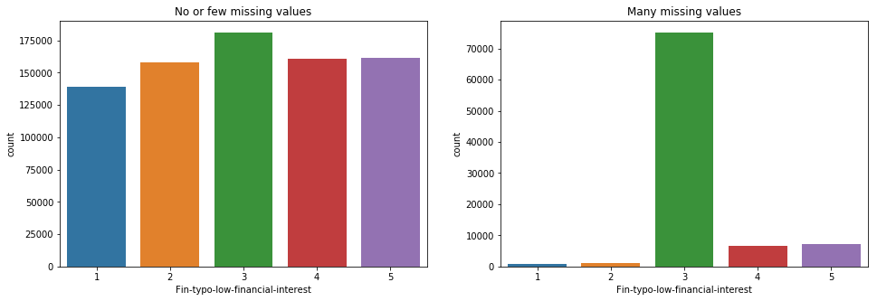

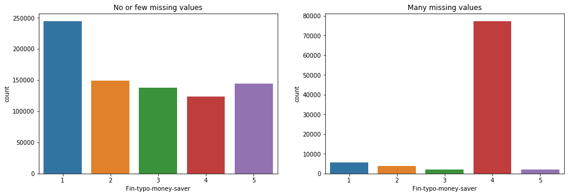

```python
# Compare the distribution of values for at least five columns where there are
# no or few missing values, between the two subsets.
def draw_countplots(df, feature_name):
    fig, (ax1, ax2) = plt.subplots(1,2,figsize = (16,5))
    ax1.set_title("No or few missing values")
    sns.countplot(df.loc[df["threshold_flag"] == 1,feature_name],ax = ax1)
    ax2.set_title("Many missing values")
    sns.countplot(df.loc[df["threshold_flag"] == 2,feature_name],ax = ax2)
    plt.show()

column_names = ["Age-estimate-name-analysis","Gender","Preferred-info-buying-channels","Fin-typo-low-financial-interest","Fin-typo-money-saver"]
for col_nam in column_names:
    draw_countplots(azdias, col_nam)
```

```python
azdias["num_NaNs_in_row"].value_counts(sort = False)
```

```
0     193588
1     238561
2     145540
3      83723
4      19226
5      18519
6      12962
7      14911
8      10459
9      17446
10     13793
11      8597
12      2714
13      1367
14      2823
```

[output cut: 37 more lines]

```python
row_NaN_pattern = azdias.groupby("num_NaNs_in_row").apply(lambda x: np.sum(x.isnull()))
azdias.groupby("num_NaNs_in_row").apply(lambda x: np.sum(x.isnull()))
```

| attribute_in_English num_NaNs_in_row | Age-estimate-name-analysis | Gender | Preferred-info-buying-channels | Fin-typo-low-financial-interest | Fin-typo-money-saver | Fin-typo-be-prepared | Fin-typo-investor | Fin-typo-inconspicuous | Fin-typo-home ownership | financial-type-description | ... | Num-6-10-family-houses-PLZ8 | Num-10p-family-houses-PLZ8 | Most-comm-build-type-PLZ8 | Num-households-within-PLZ8 | Num-buildings-within-PLZ8 | Share-of-unemployment-comm | size-community | Share-of-unemploy-relative-county | num_NaNs_in_row | threshold_flag |
| --- | --- | --- | --- | --- | --- | --- | --- | --- | --- | --- | --- | --- | --- | --- | --- | --- | --- | --- | --- | --- | --- |
| 0 | 0 | 0 | 0 | 0 | 0 | 0 | 0 | 0 | 0 | 0 | ... | 0 | 0 | 0 | 0 | 0 | 0 | 0 | 0 | 0 | 0 |
| 1 | 0 | 0 | 0 | 0 | 0 | 0 | 0 | 0 | 0 | 0 | ... | 0 | 0 | 0 | 0 | 0 | 0 | 0 | 0 | 0 | 0 |
| 2 | 0 | 0 | 0 | 0 | 0 | 0 | 0 | 0 | 0 | 0 | ... | 0 | 0 | 0 | 0 | 0 | 16 | 0 | 16 | 0 | 0 |
| 3 | 0 | 0 | 0 | 0 | 0 | 0 | 0 | 0 | 0 | 0 | ... | 0 | 0 | 0 | 0 | 0 | 1059 | 1031 | 1059 | 0 | 0 |
| 4 | 600 | 0 | 0 | 0 | 0 | 0 | 0 | 0 | 0 | 0 | ... | 0 | 0 | 0 | 0 | 0 | 1270 | 1253 | 1270 | 0 | 0 |
| 5 | 668 | 0 | 0 | 0 | 0 | 0 | 0 | 0 | 0 | 0 | ... | 0 | 0 | 0 | 0 | 0 | 782 | 768 | 782 | 0 | 0 |
| 6 | 223 | 0 | 0 | 0 | 0 | 0 | 0 | 0 | 0 | 0 | ... | 0 | 0 | 0 | 0 | 0 | 467 | 467 | 467 | 0 | 0 |
| 7 | 188 | 0 | 0 | 0 | 0 | 0 | 0 | 0 | 0 | 0 | ... | 395 | 395 | 395 | 395 | 395 | 58 | 57 | 58 | 0 | 0 |
| 8 | 252 | 0 | 0 | 0 | 0 | 0 | 0 | 0 | 0 | 0 | ... | 1876 | 1876 | 1876 | 1876 | 1876 | 84 | 81 | 84 | 0 | 0 |
| 9 | 337 | 0 | 0 | 0 | 0 | 0 | 0 | 0 | 0 | 0 | ... | 2111 | 2111 | 2111 | 2111 | 2111 | 69 | 66 | 69 | 0 | 0 |
| 10 | 255 | 0 | 1397 | 0 | 0 | 0 | 0 | 0 | 0 | 0 | ... | 1991 | 1991 | 1991 | 1991 | 1991 | 63 | 62 | 63 | 0 | 0 |
| 11 | 64 | 0 | 1625 | 0 | 0 | 0 | 0 | 0 | 0 | 0 | ... | 1407 | 1407 | 1407 | 1407 | 1407 | 61 | 53 | 61 | 0 | 0 |
| 12 | 47 | 0 | 700 | 0 | 0 | 0 | 0 | 0 | 0 | 0 | ... | 453 | 453 | 453 | 453 | 453 | 106 | 106 | 106 | 0 | 0 |
| 13 | 32 | 0 | 315 | 0 | 0 | 0 | 0 | 0 | 0 | 0 | ... | 277 | 277 | 277 | 277 | 277 | 50 | 49 | 50 | 0 | 0 |
| 14 | 21 | 0 | 142 | 0 | 0 | 0 | 0 | 0 | 0 | 0 | ... | 2219 | 2219 | 2219 | 2219 | 2219 | 49 | 49 | 49 | 0 | 0 |
| 15 | 17 | 0 | 91 | 0 | 0 | 0 | 0 | 0 | 0 | 0 | ... | 1629 | 1629 | 1629 | 1629 | 1629 | 16 | 15 | 16 | 0 | 0 |
| 16 | 14 | 0 | 48 | 0 | 0 | 0 | 0 | 0 | 0 | 0 | ... | 3806 | 3806 | 3806 | 3806 | 3806 | 7 | 6 | 7 | 0 | 0 |
| 17 | 12 | 0 | 103 | 0 | 0 | 0 | 0 | 0 | 0 | 0 | ... | 2490 | 2490 | 2490 | 2490 | 2490 | 13 | 12 | 13 | 0 | 0 |
| 18 | 22 | 0 | 67 | 0 | 0 | 0 | 0 | 0 | 0 | 0 | ... | 1381 | 1381 | 1381 | 1381 | 1381 | 14 | 12 | 14 | 0 | 0 |
| 19 | 5 | 0 | 103 | 0 | 0 | 0 | 0 | 0 | 0 | 0 | ... | 795 | 795 | 795 | 795 | 795 | 21 | 19 | 21 | 0 | 0 |
| 20 | 14 | 0 | 24 | 0 | 0 | 0 | 0 | 0 | 0 | 0 | ... | 1037 | 1037 | 1037 | 1037 | 1037 | 7 | 7 | 7 | 0 | 0 |
| 21 | 6 | 0 | 13 | 0 | 0 | 0 | 0 | 0 | 0 | 0 | ... | 411 | 411 | 411 | 411 | 411 | 6 | 5 | 6 | 0 | 0 |
| 22 | 7 | 0 | 9 | 0 | 0 | 0 | 0 | 0 | 0 | 0 | ... | 349 | 349 | 349 | 349 | 349 | 3 | 2 | 3 | 0 | 0 |
| 23 | 3 | 0 | 6 | 0 | 0 | 0 | 0 | 0 | 0 | 0 | ... | 205 | 205 | 205 | 205 | 205 | 1 | 1 | 1 | 0 | 0 |
| 24 | 7 | 0 | 14 | 0 | 0 | 0 | 0 | 0 | 0 | 0 | ... | 145 | 145 | 145 | 145 | 145 | 0 | 0 | 0 | 0 | 0 |
| 25 | 5 | 0 | 12 | 0 | 0 | 0 | 0 | 0 | 0 | 0 | ... | 113 | 113 | 113 | 113 | 113 | 2 | 2 | 2 | 0 | 0 |
| 26 | 1 | 0 | 26 | 0 | 0 | 0 | 0 | 0 | 0 | 0 | ... | 108 | 108 | 108 | 108 | 108 | 2 | 2 | 2 | 0 | 0 |
| 27 | 0 | 0 | 22 | 0 | 0 | 0 | 0 | 0 | 0 | 0 | ... | 62 | 62 | 62 | 62 | 62 | 0 | 0 | 0 | 0 | 0 |
| 28 | 1 | 0 | 9 | 0 | 0 | 0 | 0 | 0 | 0 | 0 | ... | 34 | 34 | 34 | 34 | 34 | 1 | 1 | 1 | 0 | 0 |
| 29 | 1 | 0 | 5 | 0 | 0 | 0 | 0 | 0 | 0 | 0 | ... | 26 | 26 | 26 | 26 | 26 | 0 | 0 | 0 | 0 | 0 |
| 30 | 1 | 0 | 9 | 0 | 0 | 0 | 0 | 0 | 0 | 0 | ... | 27 | 27 | 27 | 27 | 27 | 0 | 0 | 0 | 0 | 0 |
| 31 | 0 | 0 | 3 | 0 | 0 | 0 | 0 | 0 | 0 | 0 | ... | 4 | 4 | 4 | 4 | 4 | 0 | 0 | 0 | 0 | 0 |
| 32 | 0 | 0 | 4 | 0 | 0 | 0 | 0 | 0 | 0 | 0 | ... | 179 | 179 | 179 | 179 | 179 | 172 | 172 | 172 | 0 | 0 |
| 33 | 0 | 0 | 2 | 0 | 0 | 0 | 0 | 0 | 0 | 0 | ... | 2044 | 2044 | 2044 | 2044 | 2044 | 2041 | 2041 | 2041 | 0 | 0 |
| 34 | 0 | 0 | 2 | 0 | 0 | 0 | 0 | 0 | 0 | 0 | ... | 7022 | 7022 | 7022 | 7022 | 7022 | 7019 | 7019 | 7019 | 0 | 0 |
| 35 | 0 | 0 | 1 | 0 | 0 | 0 | 0 | 0 | 0 | 0 | ... | 3850 | 3850 | 3850 | 3850 | 3850 | 3849 | 3849 | 3849 | 0 | 0 |
| 36 | 2 | 0 | 0 | 0 | 0 | 0 | 0 | 0 | 0 | 0 | ... | 2937 | 2937 | 2937 | 2937 | 2937 | 2937 | 2937 | 2937 | 0 | 0 |
| 37 | 11 | 0 | 1 | 0 | 0 | 0 | 0 | 0 | 0 | 0 | ... | 2300 | 2300 | 2300 | 2300 | 2300 | 2299 | 2299 | 2299 | 0 | 0 |
| 38 | 28 | 0 | 1 | 0 | 0 | 0 | 0 | 0 | 0 | 0 | ... | 373 | 373 | 373 | 373 | 373 | 372 | 372 | 372 | 0 | 0 |
| 39 | 11 | 0 | 0 | 0 | 0 | 0 | 0 | 0 | 0 | 0 | ... | 208 | 208 | 208 | 208 | 208 | 208 | 208 | 208 | 0 | 0 |
| 40 | 8 | 0 | 0 | 0 | 0 | 0 | 0 | 0 | 0 | 0 | ... | 132 | 132 | 132 | 132 | 132 | 132 | 132 | 132 | 0 | 0 |
| 41 | 2 | 0 | 0 | 0 | 0 | 0 | 0 | 0 | 0 | 0 | ... | 76 | 76 | 76 | 76 | 76 | 76 | 76 | 76 | 0 | 0 |
| 42 | 14 | 0 | 0 | 0 | 0 | 0 | 0 | 0 | 0 | 0 | ... | 111 | 111 | 111 | 111 | 111 | 111 | 111 | 111 | 0 | 0 |
| 43 | 2 | 0 | 13 | 0 | 0 | 0 | 0 | 0 | 0 | 0 | ... | 327 | 327 | 327 | 327 | 327 | 327 | 327 | 327 | 0 | 0 |
| 44 | 0 | 0 | 46 | 0 | 0 | 0 | 0 | 0 | 0 | 0 | ... | 65 | 65 | 65 | 65 | 65 | 65 | 65 | 65 | 0 | 0 |
| 45 | 0 | 0 | 18 | 0 | 0 | 0 | 0 | 0 | 0 | 0 | ... | 27366 | 27366 | 27366 | 27366 | 27366 | 27366 | 27366 | 27366 | 0 | 0 |
| 46 | 0 | 0 | 11 | 0 | 0 | 0 | 0 | 0 | 0 | 0 | ... | 107 | 107 | 107 | 107 | 107 | 107 | 107 | 107 | 0 | 0 |
| 47 | 0 | 0 | 9 | 0 | 0 | 0 | 0 | 0 | 0 | 0 | ... | 486 | 486 | 486 | 486 | 486 | 486 | 486 | 486 | 0 | 0 |
| 48 | 0 | 0 | 1 | 0 | 0 | 0 | 0 | 0 | 0 | 0 | ... | 1 | 1 | 1 | 1 | 1 | 1 | 1 | 1 | 0 | 0 |
| 49 | 0 | 0 | 0 | 0 | 0 | 0 | 0 | 0 | 0 | 0 | ... | 45578 | 45578 | 45578 | 45578 | 45578 | 45578 | 45578 | 45578 | 0 | 0 |
| 50 | 0 | 0 | 2 | 0 | 0 | 0 | 0 | 0 | 0 | 0 | ... | 2 | 2 | 2 | 2 | 2 | 2 | 2 | 2 | 0 | 0 |

51 rows × 83 columns

```python
row_NaN_pattern = row_NaN_pattern.loc[:,np.logical_not((row_NaN_pattern == 0).all())]
```

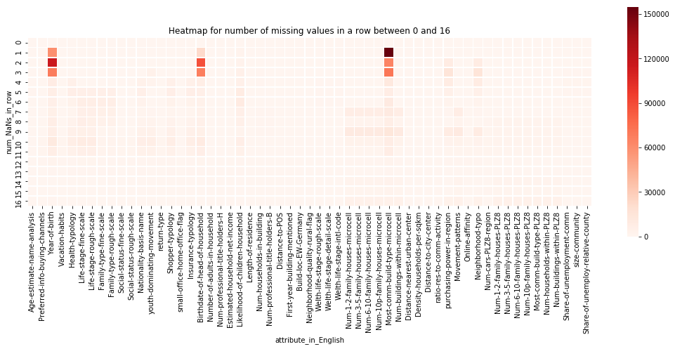

```python
fig = plt.figure(figsize=(18,6))
ax = plt.gca()
ax.set_title("Heatmap for number of missing values in a row between 0 and 16")
sns.heatmap(row_NaN_pattern[:17],annot = False, linewidths=0.5, square = True, cmap = "Reds")
```

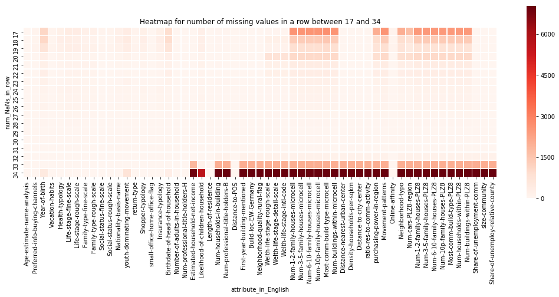

```python
fig = plt.figure(figsize=(18,6))
ax = plt.gca()
ax.set_title("Heatmap for number of missing values in a row between 17 and 34")
sns.heatmap(row_NaN_pattern[17:35],annot = False, linewidths=0.5, square = True, cmap = "Reds")
```

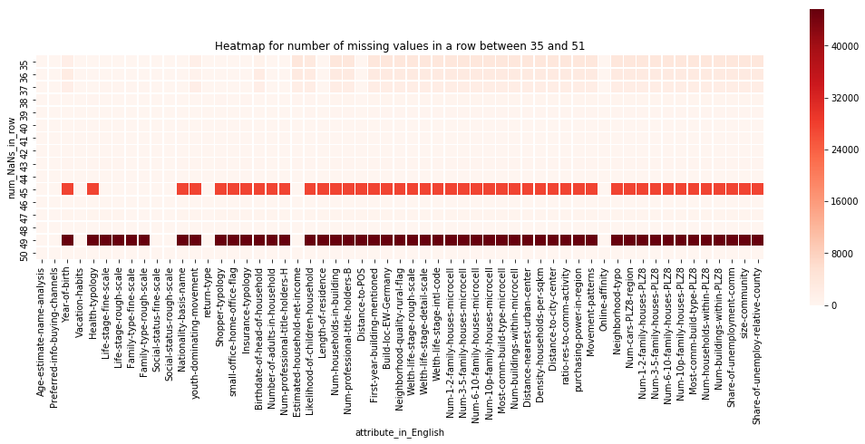

```python
fig = plt.figure(figsize=(18,6))
ax = plt.gca()
ax.set_title("Heatmap for number of missing values in a row between 35 and 51")
sns.heatmap(row_NaN_pattern[35:],annot = False, linewidths=0.5, square = True, cmap = "Reds")
```

#### Discussion 1.1.3: Assess Missing Data in Each Row

They all share these following characteristics.

1) They can be upto 60 years old 2) They are advertising-Enthusiast with restricted Cross-Channel 3) They are Nature fans 4) They are minimalistic high-income earners 5) They are incentive-receptive Normal-Returner 6) They are very high income earners 7) Their online affinity is in the middle level.

To seperate the dataset into two seperate subsets, i again assumed that number of NaNs in a row also would follow Gaussian distribution. Then, i placed all the rows that had number of NaNs less than or equal to "mean + (2 *std.dev)" in subset 1 and rest in subset 2. In normal distribution 95.5% of all data must fall within "mean +/- (2* std.dev)".

Yes, both the subsets are qualitatively different as far code frequencies are concerned as can be seen from the countplots above. We can't drop the subset where there are many NaNs in the rows.

### Step 1.2: Select and Re-Encode Features

Checking for missing data isn't the only way in which you can prepare a dataset for analysis. Since the unsupervised learning techniques to be used will only work on data that is encoded numerically, you need to make a few encoding changes or additional assumptions to be able to make progress. In addition, while almost all of the values in the dataset are encoded using numbers, not all of them represent numeric values. Check the third column of the feature summary (`feat_info`) for a summary of types of measurement.

- For numeric and interval data, these features can be kept without changes.
- Most of the variables in the dataset are ordinal in nature. While ordinal values may technically be non-linear in spacing, make the simplifying assumption that the ordinal variables can be treated as being interval in nature (that is, kept without any changes).
- Special handling may be necessary for the remaining two variable types: categorical, and 'mixed'.

In the first two parts of this sub-step, you will perform an investigation of the categorical and mixed-type features and make a decision on each of them, whether you will keep, drop, or re-encode each. Then, in the last part, you will create a new data frame with only the selected and engineered columns.

Data wrangling is often the trickiest part of the data analysis process, and there's a lot of it to be done here. But stick with it: once you're done with this step, you'll be ready to get to the machine learning parts of the project!

```python
# How many features are there of each data type?
azdias_less_NaNs = azdias.loc[azdias["threshold_flag"] == 1,:] # Taking only the subset that has only few or no missing values.

print("The number of features for each data type")
feat_info.loc[feat_info["attribute_in_English"].isin(azdias_less_NaNs.columns), "type"].value_counts()
```

```
The number of features for each data type
```

```
ordinal        49
categorical    17
numeric         7
mixed           7
interval        1
Name: type, dtype: int64
```

#### Step 1.2.1: Re-Encode Categorical Features

For categorical data, you would ordinarily need to encode the levels as dummy variables. Depending on the number of categories, perform one of the following:

- For binary (two-level) categoricals that take numeric values, you can keep them without needing to do anything.
- There is one binary variable that takes on non-numeric values. For this one, you need to re-encode the values as numbers or create a dummy variable.
- For multi-level categoricals (three or more values), you can choose to encode the values using multiple dummy variables (e.g. via [OneHotEncoder](http://scikit-learn.org/stable/modules/generated/sklearn.preprocessing.OneHotEncoder.html)), or (to keep things straightforward) just drop them from the analysis. As always, document your choices in the Discussion section.

```python
def multi_level_or_binary_level(df, feature_name):
    if (len(df[feature_name].value_counts()) > 2):
        return 1
    return 0
```

```python
# Assess categorical variables: which are binary, which are multi-level, and
# which one needs to be re-encoded?

categorical_present_index = feat_info.loc[feat_info["type"] == "categorical",:]["attribute_in_English"].isin(azdias_less_NaNs.columns)
categorical_necessary = feat_info.loc[feat_info["type"] == "categorical",:].loc[categorical_present_index,"attribute_in_English"]

def multi_level_or_binary_level(df, feature_name):
    if (len(df[feature_name].value_counts()) > 2):
        return 1
    return 0

multi_level_features, binary_level_feature = [],[]
categorical_necessary_list = [i for i in categorical_necessary]
for i in categorical_necessary_list:
    return_value = multi_level_or_binary_level(azdias_less_NaNs, i)
    if return_value == 1:
        multi_level_features.append(i)
    else:
        binary_level_feature.append(i)
```

```python
print("the binary level categorical variables are",binary_level_feature)
```

```
the binary level categorical variables are ['Gender', 'Mem-environ-sustain', 'small-office-home-office-flag', 'Insurance-typology', 'Build-loc-EW-Germany']
```

```python
print("the Multi level categorical variables are",multi_level_features)
```

[output not shown]

```python
# Re-encode categorical variable(s) to be kept in the analysis.
azdias_less_NaNs["Build-loc-EW-Germany"] = azdias_less_NaNs["Build-loc-EW-Germany"].map({"W":1,"O":2})
# azdias_less_NaNs["Welth-life-stage-detail-scale"] = azdias_less_NaNs["Welth-life-stage-detail-scale"].map({"1A":0,"1B":1,"1C":2,"1D":3,"1E":4,"2A":5,"2B":6,"2C":7,"2D":8,"3A":9,"3B":10,"3C":11,"3D":12,"4A":13,"4B":14,"4C":15,"4D":16,"4E":17,"5A":18,"5B":19,"5C":20,"5D":21,"5E":22,"5F":23,"6A":24,"6B":25,"6C":26,"6D":27,"6E":28,"6F":29,"7A":30,"7B":31,"7C":32,"7D":33,"7E":34,"8A":35,"8B":36,"8C":37,"8D":38,"9A":39,"9B":40,"9C":41,"9D":42,"9E":43})
```

```python
def print_feature_details(df, feature_name):
    for i in feature_name:
        print("\nThe name of the feature", i)
        value_counts = df[i].value_counts(normalize = True)
        print("The percentage of values in each subcategory is\n",value_counts)
        print("The cumulative sum of values in each category is\n",np.cumsum(value_counts))
        percentage_missing_value = np.sum(df[i].isnull())/len(df)
        print("The percentage of missing values is {}\n\n".format(percentage_missing_value *100))

# To decide which ones to drop and which ones to keep
print_feature_details(azdias_less_NaNs, categorical_necessary_list)
```

```
The name of the feature Gender
The percentage of values in each subcategory is
 2    0.521652
1    0.478348
Name: Gender, dtype: float64
The cumulative sum of values in each category is
 2    0.521652
1    1.000000
Name: Gender, dtype: float64
The percentage of missing values is 0.0



The name of the feature Preferred-info-buying-channels
The percentage of values in each subcategory is
 4.0    0.250051
3.0    0.185636
2.0    0.177802
5.0    0.140094
6.0    0.128913
1.0    0.117505
Name: Preferred-info-buying-channels, dtype: float64
The cumulative sum of values in each category is
 4.0    0.250051
3.0    0.435686
2.0    0.613488
5.0    0.753582
6.0    0.882495
1.0    1.000000
Name: Preferred-info-buying-channels, dtype: float64
The percentage of missing values is 0.5934173039436197



The name of the feature financial-type-description
The percentage of values in each subcategory is
 6    0.361295
1    0.246910
5    0.132880
2    0.131495
```

[output cut: 357 more lines]

```
3B    0.922641
6A    0.931241
9E    0.939297
6D    0.946966
6F    0.953775
7D    0.960510
4E    0.967229
1E    0.973626
7E    0.979476
1C    0.984928
5F    0.990337
1B    0.995478
5E    1.000000
Name: Welth-life-stage-detail-scale, dtype: float64
The percentage of missing values is 1.051382016294297
```

```python
drop_features = ["small-office-home-office-flag"]
azdias_less_NaNs.drop(drop_features, axis = 1, inplace=True)

# using dummies on multi-level categorical values
def convert_column_dtypes_to_str(df, feature_name):
    for i in feature_name:
        df[i] = df[i].astype(str)
    return df
```

```python
azdias_less_NaNs = convert_column_dtypes_to_str(azdias_less_NaNs, multi_level_features)
dummies_multi_level = pd.get_dummies(azdias_less_NaNs[multi_level_features], columns = multi_level_features)
azdias_less_NaNs.drop(multi_level_features, inplace=True, axis = 1)
azdias_less_NaNs = pd.concat([azdias_less_NaNs, dummies_multi_level], axis = 1)
print("The shape of the dataframe after adding dummies from multi-level categorical variables {}".format(azdias_less_NaNs.shape))
del dummies_multi_level
```

```
The shape of the dataframe after adding dummies from multi-level categorical variables (800280, 201)
```

#### Discussion 1.2.1: Re-Encode Categorical Features

Note: I have converted the German column names to English column names just for ease of understanding.

I decided to keep all the multi-level categorical columns as all of them have acceptable level of missing values as well as variance of its values is nowhere near zero. However i have decided to cast aside a binary level categorical variable, SOHO_KZ, as the variance of its values is near zero. In office-home-office-flag, little over 99% of all values fall in one category and the rest in another so it is unlikely to contribute much to our clustering.

However, all multi-level categorical columns were converted to string dtype and get_dummies applied over it.

#### Step 1.2.2: Engineer Mixed-Type Features

There are a handful of features that are marked as "mixed" in the feature summary that require special treatment in order to be included in the analysis. There are two in particular that deserve attention; the handling of the rest are up to your own choices:

- "PRAEGENDE_JUGENDJAHRE" combines information on three dimensions: generation by decade, movement (mainstream vs. avantgarde), and nation (east vs. west). While there aren't enough levels to disentangle east from west, you should create two new variables to capture the other two dimensions: an interval-type variable for decade, and a binary variable for movement.
- "CAMEO_INTL_2015" combines information on two axes: wealth and life stage. Break up the two-digit codes by their 'tens'-place and 'ones'-place digits into two new ordinal variables (which, for the purposes of this project, is equivalent to just treating them as their raw numeric values).
- If you decide to keep or engineer new features around the other mixed-type features, make sure you note your steps in the Discussion section.

Be sure to check `Data_Dictionary.md` for the details needed to finish these tasks.

```python
mixed_features = feat_info[feat_info["type"] == "mixed"]["attribute_in_English"]
mixed_features_list = [i for i in mixed_features]
print_feature_details(azdias_less_NaNs, mixed_features_list)
```

```
The name of the feature Life-stage-fine-scale
The percentage of values in each subcategory is
 1.0     0.078332
5.0     0.069874
6.0     0.057796
2.0     0.049541
8.0     0.038501
11.0    0.033838
29.0    0.033462
7.0     0.033290
13.0    0.033082
10.0    0.032644
31.0    0.029837
12.0    0.029718
30.0    0.028432
15.0    0.025305
3.0     0.025023
19.0    0.024789
37.0    0.023449
4.0     0.021976
14.0    0.021971
20.0    0.021723
32.0    0.021124
39.0    0.020294
40.0    0.018916
27.0    0.018487
16.0    0.018186
38.0    0.017528
35.0    0.017450
34.0    0.016684
21.0    0.016207
9.0     0.016150
28.0    0.015476
24.0    0.015344
25.0    0.013233
36.0    0.012935
23.0    0.011567
22.0    0.009179
18.0    0.009129
33.0    0.007686
```

[output cut: 217 more lines]

```
The percentage of values in each subcategory is
 1.0    0.644825
5.0    0.125639
2.0    0.090882
4.0    0.073168
3.0    0.065485
Name: Most-comm-build-type-PLZ8, dtype: float64
The cumulative sum of values in each category is
 1.0    0.644825
5.0    0.770464
2.0    0.861346
4.0    0.934515
3.0    1.000000
Name: Most-comm-build-type-PLZ8, dtype: float64
The percentage of missing values is 3.1956315289648622
```

```python
# Convert mixed categorical variables to float
def convert_column_to_float_dtype(df, lst):
    for i in lst:
        df[i] = df[i].astype(float)
    return df

azdias_less_NaNs = convert_column_to_float_dtype(azdias_less_NaNs, mixed_features_list)
```

```python
# Investigate "PRAEGENDE_JUGENDJAHRE" and engineer two new variables.
azdias_less_NaNs["youth-dominating-movement_decade"] = azdias_less_NaNs["youth-dominating-movement"].map({1:1,2:1,3:2,4:2,5:3,6:3,7:3,8:4,9:4,10:5,11:5,12:5,13:5,14:6,15:6})
azdias_less_NaNs["youth-dominating-movement_movement"] = azdias_less_NaNs["youth-dominating-movement"].map({1:1,3:1,5:1,8:1,10:1,12:1,14:1,2:2,4:2,6:2,7:2,9:2,11:2,13:2,15:2})
azdias_less_NaNs.drop("youth-dominating-movement", axis = 1, inplace=True)
print(azdias_less_NaNs.shape)
```

```
(800280, 202)
```

```python
# Below ES stands for economic status and LS stands for life stage
azdias_less_NaNs["Welth-life-stage-intl-code_ES"] = azdias_less_NaNs["Welth-life-stage-intl-code"].apply(lambda x: (x - (x % 10))/10)
azdias_less_NaNs["Welth-life-stage-intl-code_LS"] = azdias_less_NaNs["Welth-life-stage-intl-code"].apply(lambda x: x % 10)
azdias_less_NaNs.drop("Welth-life-stage-intl-code", axis = 1, inplace = True)
print(azdias_less_NaNs.shape)
```

```
(800280, 203)
```

```python
# Adding a new feature to denote whether a neighbourhood belongs to a rural or urban area.
azdias_less_NaNs["Neighborhood-quality-rural-urban"] = azdias_less_NaNs["Neighborhood-quality-rural-flag"].map({0:1,1:1,2:1,3:1,4:1,5:1,7:2,8:2})
print(azdias_less_NaNs.shape)
```

```
(800280, 204)
```

```python
# droping "Life-stage-fine-scale" and "Life-stage-rough-scale"
azdias_less_NaNs.drop(["Life-stage-fine-scale","Life-stage-rough-scale"], axis = 1, inplace = True)
print(azdias_less_NaNs.shape)
```

```
(800280, 202)
```

#### Discussion 1.2.2: Engineer Mixed-Type Features

I have re-engineered "PRAEGENDE_JUGENDJAHRE" and "CAMEO_INTL_2015" into two new features and dropped the original feature from the dataset.

Also, I have used "WOHNLAGE" to add one more feature to the dataset even as i keep the original feature alo. This new feature will tell whether the neighbourhood belongs to the urban or rural area.

When we consider "KBA05_BAUMAX" and "PLZ8_BAUMAX" they are mixed because they have two information 1) how many families reside in a bulding and 2) if the building is a microcell or a family home respectively. Even if we split them into two features, the housing type variable will have zero variability and that is highly unlikely to contribute anything to the task at hand.

When we consider "LP_LEBENSPHASE_FEIN", its sub-categories seem to give information for atleast 6 different variables like Martial status, Income level, Age, Homeownership, living with family, with or without children etc.., However none of the sub-categories all 6 potential variable information. Some subcategories have information for only one variable. For instance, "single independent persons" subcategory denotes that the person is single and "Independent persons" is at best ambiguous. This mixed variable can't be reliably split with the information we have. When we consider "LP_LEBENSPHASE_GROB", this subcategory is also afflicted with the same problem as "LP_LEBENSPHASE_FEIN", looks as if it has great potential but under delivers. Can't be reliably split. Also, these features violate rules of tidy data that each column should represent only one characteristic of the dataset. Moreover, given that the information contained in this feature is already present in other features, i have decided to drop both of them.

#### Step 1.2.3: Complete Feature Selection

In order to finish this step up, you need to make sure that your data frame now only has the columns that you want to keep. To summarize, the dataframe should consist of the following:

- All numeric, interval, and ordinal type columns from the original dataset.
- Binary categorical features (all numerically-encoded).
- Engineered features from other multi-level categorical features and mixed features.

Make sure that for any new columns that you have engineered, that you've excluded the original columns from the final dataset. Otherwise, their values will interfere with the analysis later on the project. For example, you should not keep "PRAEGENDE_JUGENDJAHRE", since its values won't be useful for the algorithm: only the values derived from it in the engineered features you created should be retained. As a reminder, your data should only be from **the subset with few or no missing values**.

```python
# If there are other re-engineering tasks you need to perform, make sure you
# take care of them here. (Dealing with missing data will come in step 2.1.)

print("The number of numeric, interval and ordinal variables present in the original dataset:")
print(feat_info["type"].value_counts())

print("\nThe number of numeric, interval and ordinal variables present in the present dataset:\n")
print(feat_info.loc[feat_info["attribute_in_English"].isin(azdias_less_NaNs.columns),"type"].value_counts())
```

```
The number of numeric, interval and ordinal variables present in the original dataset:
ordinal        49
categorical    21
numeric         7
mixed           7
interval        1
Name: type, dtype: int64

The number of numeric, interval and ordinal variables present in the present dataset:

ordinal        49
numeric         7
categorical     4
mixed           3
interval        1
Name: type, dtype: int64
```

```python
# Do whatever you need to in order to ensure that the dataframe only contains
# the columns that should be passed to the algorithm functions.

azdias_less_NaNs.drop(["threshold_flag","num_NaNs_in_row"], axis = 1, inplace = True)
# Droping the columns i have added to manipulate the data frame.
```

### Step 1.3: Create a Cleaning Function

Even though you've finished cleaning up the general population demographics data, it's important to look ahead to the future and realize that you'll need to perform the same cleaning steps on the customer demographics data. In this substep, complete the function below to execute the main feature selection, encoding, and re-engineering steps you performed above. Then, when it comes to looking at the customer data in Step 3, you can just run this function on that DataFrame to get the trimmed dataset in a single step.

```python
def clean_data(df, feat_info, missing_or_unknown_lst):
    """
    Perform feature trimming, re-encoding, and engineering for demographics
    data

    INPUT: Demographics DataFrame
    OUTPUT: Trimmed and cleaned demographics DataFrame
    """

    # Put in code here to execute all main cleaning steps:
    # convert missing value codes into NaNs, ...
    dict_columns_missing_code = {i[0]: i[1] for i in zip(df.columns, missing_or_unknown_lst)}
    df.fillna(np.NaN, inplace=True)  # this line is redundant
    df[df.isin(dict_columns_missing_code)] = np.NaN
    blanks_in_columns = np.sum(df.isnull(), axis=0)

    # remove selected columns and rows, ...
    Std_num_missing_values = np.std(blanks_in_columns)
    Avg_num_missing_values = np.mean(blanks_in_columns)
    Upper_limit = Avg_num_missing_values + (3 * Std_num_missing_values)
    outlier_index = blanks_in_columns[blanks_in_columns > Upper_limit].index
    df.drop(labels=outlier_index, axis=1, inplace=True)

    if ((df.columns == "Academic-title-flag").any()):
        df.drop("Academic-title-flag", axis=1, inplace=True)

    if ((df.columns == "Best-ager-typology").any()):
        df.drop("Best-ager-typology", axis=1, inplace=True)

    if ((df.columns == "Consumer-pattern-past-12-months").any()):
        df.drop("Consumer-pattern-past-12-months", axis=1, inplace=True)

    if((df.columns == "Type-of-building-R-C").any()):
        df.drop("Type-of-building-R-C", axis=1, inplace=True)

    df["num_NaNs_in_row"] = np.sum(df.isnull(), axis=1)
    NaN_row_std_dev = np.std(df["num_NaNs_in_row"])
    NaN_row_mean = np.mean(df["num_NaNs_in_row"])
    NaN_row_threshold = NaN_row_mean + 2 * (NaN_row_std_dev)
    df["threshold_flag"] = df["num_NaNs_in_row"].apply(lambda x: 1 if x <= NaN_row_threshold else 2)
    df = df.loc[df["threshold_flag"] == 1, :]

    # select, re-encode, and engineer column values.
    categorical_present_index = feat_info.loc[feat_info["type"] == "categorical", :]["attribute_in_English"].isin(
        df.columns)
    categorical_necessary = feat_info.loc[feat_info["type"] == "categorical", :].loc[
        categorical_present_index, "attribute_in_English"]

    if ((df.columns == "Build-loc-EW-Germany").any()):
        df["Build-loc-EW-Germany"] = df["Build-loc-EW-Germany"].map({"W": 1, "O": 2})

    multi_level_features, binary_level_feature = [],[]
    categorical_necessary_list = [i for i in categorical_necessary]
    for i in categorical_necessary_list:
        return_value = multi_level_or_binary_level(df, i)
        if return_value == 1:
            multi_level_features.append(i)
        else:
            binary_level_feature.append(i)

    if ((df.columns == "small-office-home-office-flag").any()):
        df.drop("small-office-home-office-flag", axis=1, inplace=True)

    df = convert_column_dtypes_to_str(df, multi_level_features)

    dummies_multi_level = pd.get_dummies(df[multi_level_features], columns=multi_level_features)
    df.drop(multi_level_features, inplace=True, axis=1)
    df = pd.concat([df, dummies_multi_level], axis=1)
    del dummies_multi_level

    mixed_features = feat_info[feat_info["type"] == "mixed"]["attribute_in_English"]
    mixed_features_list = [i for i in mixed_features]
    azdias_less_NaNs = convert_column_to_float_dtype(df, mixed_features_list)

    if ((df.columns == "youth-dominating-movement").any()):
        df["youth-dominating-movement_decade"] = df["youth-dominating-movement"].map(
            {1: 1, 2: 1, 3: 2, 4: 2, 5: 3, 6: 3, 7: 3, 8: 4, 9: 4, 10: 5, 11: 5, 12: 5, 13: 5,14: 6, 15: 6})
        df["youth-dominating-movement_movement"] = df["youth-dominating-movement"].map(
            {1: 1, 3: 1, 5: 1, 8: 1, 10: 1, 12: 1, 14: 1, 2: 2, 4: 2, 6: 2, 7: 2, 9: 2, 11: 2,13: 2, 15: 2})
        df.drop("youth-dominating-movement", axis=1, inplace=True)

    if ((df.columns == "Welth-life-stage-intl-code").any()):
        df["Welth-life-stage-intl-code_ES"] = df["Welth-life-stage-intl-code"].apply(lambda x: (x - (x % 10)) / 10)
        df["Welth-life-stage-intl-code_LS"] = df["Welth-life-stage-intl-code"].apply(lambda x: x % 10)
        df.drop("Welth-life-stage-intl-code", axis=1, inplace=True)

    if ((df.columns == "Neighborhood-quality-rural-flag").any()):
        df["Neighborhood-quality-rural-urban"] = df["Neighborhood-quality-rural-flag"].map({0: 1, 1: 1, 2: 1, 3: 1, 4: 1, 5: 1, 7: 2, 8: 2})

    if ((df.columns == "Life-stage-fine-scale").any()):
        df.drop("Life-stage-fine-scale", axis=1, inplace=True)

    if ((df.columns == "Life-stage-rough-scale").any()):
        df.drop("Life-stage-rough-scale", axis=1, inplace=True)

    df.drop(["threshold_flag","num_NaNs_in_row"], axis = 1, inplace = True)

        # Return the cleaned dataframe.
    return df
```

```python
# Find out if the clean_data function is working as intended.

df_azdias = pd.read_csv("./Udacity_AZDIAS_Subset.csv", sep = ";")
df_azdias.columns = feat_info["attribute_in_English"]
df_azdias = clean_data(df_azdias, feat_info,missing_or_unknown_lst)

print((azdias_less_NaNs.fillna(-5) == df_azdias.fillna(-5)).all()[0])
del df_azdias
```

```
True
```

## Step 2: Feature Transformation

### Step 2.1: Apply Feature Scaling

Before we apply dimensionality reduction techniques to the data, we need to perform feature scaling so that the principal component vectors are not influenced by the natural differences in scale for features. Starting from this part of the project, you'll want to keep an eye on the [API reference page for sklearn](http://scikit-learn.org/stable/modules/classes.html) to help you navigate to all of the classes and functions that you'll need. In this substep, you'll need to check the following:

- sklearn requires that data not have missing values in order for its estimators to work properly. So, before applying the scaler to your data, make sure that you've cleaned the DataFrame of the remaining missing values before applying your scaler. This can be as simple as just removing all data points with missing data, or applying an [Imputer](http://scikit-learn.org/stable/modules/generated/sklearn.preprocessing.Imputer.html) to replace all missing values. You might also try a more complicated procedure where you temporarily remove missing values in order to compute the scaling parameters before re-introducing those missing values and applying imputation. Think about how much missing data you have and what possible effects each approach might have on your analysis, and justify your decision in the discussion section below.
- For the actual scaling function, a [StandardScaler](http://scikit-learn.org/stable/modules/generated/sklearn.preprocessing.StandardScaler.html) instance is suggested, scaling each feature to mean 0 and standard deviation 1.
- For these classes, you can make use of the `.fit_transform()` method to both fit a procedure to the data as well as apply the transformation to the data at the same time. Don't forget to keep the fit sklearn objects handy, since you'll be applying them to the customer demographics data towards the end of the project.

```python
# If you've not yet cleaned the dataset of all NaN values, then investigate and
# do that now.

# Number of missing values in each columns.
np.sum(azdias_less_NaNs.isnull())

# Since i have so many missing values simply droping all rows that has missing values would be droping too much valuable
# information. So i would impute the values using "median" strategy.
```

```
Age-estimate-name-analysis              2803
Gender                                     0
Fin-typo-low-financial-interest            0
Fin-typo-money-saver                       0
Fin-typo-be-prepared                       0
Fin-typo-investor                          0
Fin-typo-inconspicuous                     0
Fin-typo-home ownership                    0
Year-of-birth                         310924
Mem-environ-sustain                        0
Health-typology                        36726
return-type                             4749
persnlity-typo-socially-minded             0
persnlity-typo-family-minded               0
persnlity-typo-religious                   0
persnlity-typo-materialistic               0
persnlity-typo-dreamful                    0
persnlity-typo-sensual-minded              0
persnlity-typo-event-oriented              0
persnlity-typo-cultural-minded             0
persnlity-typo-rational                    0
persnlity-typo-critical-minded             0
persnlity-typo-dominant-minded             0
persnlity-typo-combative attitude          0
persnlity-typo-dutiful                     0
persnlity-typo-tradional-minded            0
Insurance-typology                     36726
Birthdate-of-head-of-household        230479
Number-of-adults-in-household              0
Num-professional-title-holders-H           0
                                       ...
Welth-life-stage-detail-scale_5C           0
Welth-life-stage-detail-scale_5D           0
Welth-life-stage-detail-scale_5E           0
Welth-life-stage-detail-scale_5F           0
Welth-life-stage-detail-scale_6A           0
Welth-life-stage-detail-scale_6B           0
Welth-life-stage-detail-scale_6C           0
Welth-life-stage-detail-scale_6D           0
Welth-life-stage-detail-scale_6E           0
Welth-life-stage-detail-scale_6F           0
Welth-life-stage-detail-scale_7A           0
Welth-life-stage-detail-scale_7B           0
Welth-life-stage-detail-scale_7C           0
Welth-life-stage-detail-scale_7D           0
Welth-life-stage-detail-scale_7E           0
Welth-life-stage-detail-scale_8A           0
Welth-life-stage-detail-scale_8B           0
Welth-life-stage-detail-scale_8C           0
Welth-life-stage-detail-scale_8D           0
Welth-life-stage-detail-scale_9A           0
Welth-life-stage-detail-scale_9B           0
Welth-life-stage-detail-scale_9C           0
Welth-life-stage-detail-scale_9D           0
Welth-life-stage-detail-scale_9E           0
Welth-life-stage-detail-scale_nan          0
youth-dominating-movement_decade       28770
youth-dominating-movement_movement     28770
Welth-life-stage-intl-code_ES           8414
Welth-life-stage-intl-code_LS           8414
Neighborhood-quality-rural-urban        2213
Length: 200, dtype: int64
```

```python
imp = Imputer(missing_values='NaN', strategy='median', axis=0)
model_imp = imp.fit(azdias_less_NaNs)
X = model_imp.transform(azdias_less_NaNs)
```

```python
# Apply feature scaling to the general population demographics data.
scaler=StandardScaler()
model_scaler = scaler.fit(X)
X = model_scaler.transform(X)
```

```python
print(X.shape)
```

```
(800280, 200)
```

### Discussion 2.1: Apply Feature Scaling

Since my dataset has so many missing values simply droping all rows that have missing values would be droping too much valuable information. So i imputed the values using "median" strategy and then scaled it using standard scaler as suggested. The reason i have chosen "median" strategy is to avoid the effect of outliers as well as many features of our dataset is either categorical or ordinal so "mean" startegy would result in a decimal and it probably won't make much sense.

### Step 2.2: Perform Dimensionality Reduction

On your scaled data, you are now ready to apply dimensionality reduction techniques.

- Use sklearn's [PCA](http://scikit-learn.org/stable/modules/generated/sklearn.decomposition.PCA.html) class to apply principal component analysis on the data, thus finding the vectors of maximal variance in the data. To start, you should not set any parameters (so all components are computed) or set a number of components that is at least half the number of features (so there's enough features to see the general trend in variability).
- Check out the ratio of variance explained by each principal component as well as the cumulative variance explained. Try plotting the cumulative or sequential values using matplotlib's [`plot()`](https://matplotlib.org/api/_as_gen/matplotlib.pyplot.plot.html) function. Based on what you find, select a value for the number of transformed features you'll retain for the clustering part of the project.
- Once you've made a choice for the number of components to keep, make sure you re-fit a PCA instance to perform the decided-on transformation.

```python
# Apply PCA to the data.
pca = PCA(random_state=42)
X_pca = pca.fit_transform(X)
```

```
Text(0.5,1,'Explained Variance Per Principal Component')
```

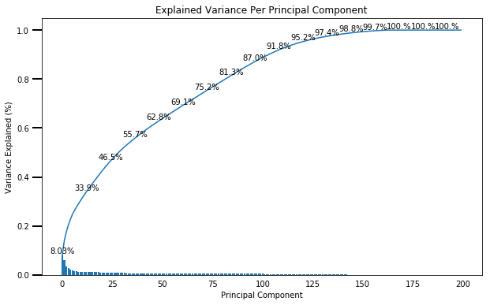

```python
# Investigate the variance accounted for by each principal component.
num_of_components = len(pca.explained_variance_ratio_)
ind = np.arange(num_of_components)
vals = pca.explained_variance_ratio_
cumvals = np.cumsum(vals)
plt.figure(figsize=(10, 6))
ax = plt.subplot(111)
ax.bar(ind, vals)
ax.plot(ind, cumvals)
for i in range(num_of_components):
    if i % 12 == 0:
        ax.annotate(r"%s%%" % ((str(cumvals[i] * 100)[:4])), (ind[i] + 0.2, cumvals[i]), va="bottom", ha="center",fontsize=10)
ax.xaxis.set_tick_params(width=0)
ax.yaxis.set_tick_params(width=2, length=12)
ax.set_xlabel("Principal Component")
ax.set_ylabel("Variance Explained (%)")
#ax.set_xlim(0,num_of_components)
#ax.set_ylim(0,1)
plt.title('Explained Variance Per Principal Component')
```

```python
print(cumvals)
```

```
[ 0.08037064  0.14031835  0.17496525  0.20340764  0.22618001  0.2462344
  0.26204184  0.27631     0.2895983   0.30254992  0.31520793  0.3273817
  0.3390666   0.3505622   0.36179257  0.37295898  0.38390099  0.39470252
  0.40539898  0.41584328  0.42615227  0.43636927  0.44633401  0.455944
  0.46515385  0.47417679  0.48285434  0.49124435  0.49953207  0.50764208
  0.51527926  0.52270125  0.52991754  0.53693257  0.54387194  0.55056909
  0.5571702   0.56359883  0.56994166  0.57619815  0.58232554  0.58833122
  0.59425377  0.60008036  0.60577914  0.61141665  0.61699601  0.62254299
  0.62806814  0.63353883  0.63897461  0.64436831  0.64970761  0.65503711
  0.66032473  0.66557298  0.67080646  0.67600462  0.68119966  0.68637706
  0.691544    0.69669692  0.70184203  0.70697712  0.71209559  0.71720461
  0.72231056  0.72740617  0.73249287  0.73757413  0.74265064  0.74772526
  0.752786    0.75784501  0.7628962   0.76794491  0.77298638  0.77802485
  0.78306278  0.78809823  0.79312923  0.79815499  0.80317518  0.80819082
  0.81319685  0.81817027  0.82313531  0.82807744  0.83300631  0.83791637
  0.84280543  0.84761727  0.85233923  0.85701746  0.86164073  0.8661979
  0.8707176   0.87517219  0.87961136  0.88402155  0.88824804  0.8923284
  0.89633454  0.90031219  0.90419863  0.90799294  0.91165052  0.91530035
  0.91891085  0.92232546  0.92565027  0.92892594  0.93198317  0.93502105
  0.93785872  0.94051718  0.94312463  0.94570688  0.9481994   0.9505757
  0.95284629  0.95507804  0.95724871  0.95933041  0.96128771  0.96320311
  0.96509978  0.96692825  0.96864433  0.97028224  0.97177549  0.9732264
  0.97467483  0.97603864  0.97738651  0.97867784  0.97993324  0.98114592
  0.98232263  0.98345605  0.98452217  0.98553708  0.98654953  0.98751128
  0.98845248  0.98937462  0.99024628  0.9911102   0.99193652  0.99272702
  0.99347654  0.99417714  0.99486034  0.99552905  0.99613898  0.99674315
  0.99730814  0.9978182   0.99827183  0.9987148   0.99915038  0.9995349
  0.99979852  1.          1.          1.          1.          1.          1.
  1.          1.          1.          1.          1.          1.          1.
  1.          1.          1.          1.          1.          1.          1.
  1.          1.          1.          1.          1.          1.          1.
  1.          1.          1.          1.          1.          1.          1.
  1.          1.          1.        ]
```

```python
# Re-apply PCA to the data while selecting for number of components to retain.
pca = PCA(96, random_state=42)
model_pca = pca.fit(X)
X_pca = model_pca.transform(X)
num_of_components = len(pca.explained_variance_ratio_)
ind = np.arange(num_of_components)
vals = pca.explained_variance_ratio_
cumvals = np.cumsum(vals)
```

```
Text(0.5,1,'Explained Variance Per Principal Component')
```

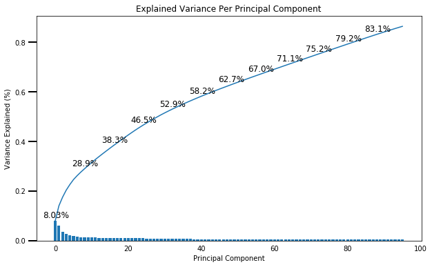

```python
plt.figure(figsize=(10, 6))
ax = plt.subplot(111)
ax.bar(ind, vals)
ax.plot(ind, cumvals)
for i in range(num_of_components):
    if i % 8 == 0:
        ax.annotate(r"%s%%" % ((str(cumvals[i] * 100)[:4])), (ind[i] + 0.2, cumvals[i]+0.003), va="bottom", ha="center",fontsize=12)
ax.xaxis.set_tick_params(width=0)
ax.yaxis.set_tick_params(width=2, length=12)
ax.set_xlabel("Principal Component")
ax.set_ylabel("Variance Explained (%)")
plt.title('Explained Variance Per Principal Component')
```

### Discussion 2.2: Perform Dimensionality Reduction

I have decided to retain around 85% of variability so i have chosen 96 as my number of components as the acceptable variance explained in factor analysis for a construct to be valid is sixty per cent. The reason i have chosen to stop with around 85% variance is from here for every 2% additional variability we need to add 6 more features and the "curse of dimensionality" will be even more pronounced than what we have now.

### Step 2.3: Interpret Principal Components

Now that we have our transformed principal components, it's a nice idea to check out the weight of each variable on the first few components to see if they can be interpreted in some fashion.

As a reminder, each principal component is a unit vector that points in the direction of highest variance (after accounting for the variance captured by earlier principal components). The further a weight is from zero, the more the principal component is in the direction of the corresponding feature. If two features have large weights of the same sign (both positive or both negative), then increases in one tend expect to be associated with increases in the other. To contrast, features with different signs can be expected to show a negative correlation: increases in one variable should result in a decrease in the other.

- To investigate the features, you should map each weight to their corresponding feature name, then sort the features according to weight. The most interesting features for each principal component, then, will be those at the beginning and end of the sorted list. Use the data dictionary document to help you understand these most prominent features, their relationships, and what a positive or negative value on the principal component might indicate.
- You should investigate and interpret feature associations from the first three principal components in this substep. To help facilitate this, you should write a function that you can call at any time to print the sorted list of feature weights, for the *i*-th principal component. This might come in handy in the next step of the project, when you interpret the tendencies of the discovered clusters.

```python
# Function to print out the eigen vectors of the ith principal component.
def get_eigen_vectors_ith_component(pca, i, columns):
    df_eigen_vector = pd.DataFrame(pca.components_[i], index=columns, columns=["eigen_vector"])
    print(df_eigen_vector.sort_values(by="eigen_vector", axis=0, ascending=False))
    return df_eigen_vector
```

```python
# Map weights for the first principal component to corresponding feature names
# and then print the linked values, sorted by weight.
# HINT: Try defining a function here or in a new cell that you can reuse in the
# other cells.

df_eigen1 = get_eigen_vectors_ith_component(pca,0,azdias_less_NaNs.columns)
```

```
                                    eigen_vector
Social-status-rough-scale_1.0           0.190846
Num-6-10-family-houses-PLZ8             0.181366
Welth-life-stage-intl-code_ES           0.179341
Estimated-household-net-income          0.176638
Num-10p-family-houses-PLZ8              0.176122
Most-comm-build-type-PLZ8               0.171770
size-community                          0.159098
Density-households-per-sqkm             0.156813
Fin-typo-home ownership                 0.143555
Most-comm-build-type-microcell          0.139365
Num-10p-family-houses-microcell         0.128560
Social-status-fine-scale_1.0            0.124670
Num-3-5-family-houses-PLZ8              0.124293
Num-6-10-family-houses-microcell        0.115287
Share-of-unemployment-comm              0.114420
Num-households-in-building              0.112866
Social-status-fine-scale_2.0            0.112051
Welth-life-stage-rough-scale_9          0.111319
Fin-typo-money-saver                    0.109716
financial-type-description_1            0.108560
Share-of-unemploy-relative-county       0.108303
Welth-life-stage-rough-scale_8          0.090644
Family-type-rough-scale_1.0             0.081246
Family-type-fine-scale_1.0              0.081246
persnlity-typo-dutiful                  0.079250
persnlity-typo-religious                0.075591
Energy-consumption-typology_5           0.072321
youth-dominating-movement_decade        0.068234
persnlity-typo-rational                 0.065225
Welth-life-stage-detail-scale_8A        0.062197
...                                          ...
Family-type-rough-scale_5.0            -0.060680
Num-cars-PLZ8-region                   -0.061230
Welth-life-stage-rough-scale_3         -0.064702
Nationality-basis-name_1.0             -0.065535
Neighborhood-quality-rural-flag        -0.069075
Welth-life-stage-rough-scale_4         -0.071459
financial-type-description_2           -0.075897
Number-of-adults-in-household          -0.077784
```

[output cut: 9 more lines]

```
Social-status-fine-scale_10.0          -0.104945
Welth-life-stage-intl-code_LS          -0.107153
Social-status-fine-scale_9.0           -0.108217
Social-status-rough-scale_4.0          -0.110436
Neighborhood-quality-rural-urban       -0.117427
Distance-to-city-center                -0.129303
Num-buildings-within-PLZ8              -0.132700
Distance-to-POS                        -0.135834
Num-buildings-within-microcell         -0.177814
Num-1-2-family-houses-PLZ8             -0.181214
Fin-typo-low-financial-interest        -0.183451
Num-1-2-family-houses-microcell        -0.183591
Movement-patterns                      -0.200301

[200 rows x 1 columns]
```

```python
# Map weights for the second principal component to corresponding feature names
# and then print the linked values, sorted by weight.

df_eigen2 = get_eigen_vectors_ith_component(pca,1,azdias_less_NaNs.columns)
```

```
                                    eigen_vector
Age-estimate-name-analysis              0.222068
Fin-typo-be-prepared                    0.214615
Energy-consumption-typology_3           0.189319
persnlity-typo-event-oriented           0.165631
persnlity-typo-sensual-minded           0.156445
return-type                             0.153045
Likelihood-of-children-household        0.126713
Preferred-info-buying-channels_2.0      0.104962
financial-type-description_5            0.098923
Social-status-fine-scale_1.0            0.091443
Fin-typo-low-financial-interest         0.091070
financial-type-description_2            0.090064
Fin-typo-home ownership                 0.081720
Preferred-info-buying-channels_1.0      0.068520
Shopper-typology_3.0                    0.068408
financial-type-description_6            0.064464
Nationality-basis-name_1.0              0.063926
Density-households-per-sqkm             0.062924
size-community                          0.062535
persnlity-typo-critical-minded          0.061974
Num-6-10-family-houses-PLZ8             0.061131
Num-10p-family-houses-PLZ8              0.057619
Vacation-habits_4.0                     0.056641
Most-comm-build-type-PLZ8               0.056410
Family-type-rough-scale_1.0             0.055917
Family-type-fine-scale_1.0              0.055917
Length-of-residence                     0.054527
Welth-life-stage-intl-code_ES           0.052675
Social-status-fine-scale_3.0            0.049882
Most-comm-build-type-microcell          0.049682
...                                          ...
Energy-consumption-typology_1          -0.051488
persnlity-typo-socially-minded         -0.052418
Preferred-info-buying-channels_4.0     -0.053147
Num-buildings-within-microcell         -0.056885
Movement-patterns                      -0.057909
Num-1-2-family-houses-PLZ8             -0.059703
Number-of-adults-in-household          -0.064051
Family-type-rough-scale_4.0            -0.068892
```

[output cut: 9 more lines]

```
financial-type-description_1           -0.131032
persnlity-typo-cultural-minded         -0.149470
Online-affinity                        -0.155760
persnlity-typo-rational                -0.163182
Birthdate-of-head-of-household         -0.183548
Year-of-birth                          -0.191320
persnlity-typo-dutiful                 -0.195162
persnlity-typo-tradional-minded        -0.196633
persnlity-typo-religious               -0.200320
Fin-typo-investor                      -0.202735
Fin-typo-inconspicuous                 -0.209970
Fin-typo-money-saver                   -0.223181
youth-dominating-movement_decade       -0.236459

[200 rows x 1 columns]
```

```python
# Map weights for the third principal component to corresponding feature names
# and then print the linked values, sorted by weight.

df_eigen3 = get_eigen_vectors_ith_component(pca,2,azdias_less_NaNs.columns)
```

```
                                    eigen_vector
persnlity-typo-dreamful                 0.314684
persnlity-typo-family-minded            0.258824
persnlity-typo-socially-minded          0.255666
persnlity-typo-cultural-minded          0.253559
financial-type-description_5            0.132180
Fin-typo-low-financial-interest         0.128496
Energy-consumption-typology_1           0.124217
Shopper-typology_0.0                    0.122875
persnlity-typo-religious                0.117235
youth-dominating-movement_movement      0.094948
Mem-environ-sustain                     0.094948
persnlity-typo-materialistic            0.093893
size-community                          0.072921
Density-households-per-sqkm             0.071399
Social-status-rough-scale_5.0           0.069865
Social-status-fine-scale_10.0           0.069865
return-type                             0.063438
Shopper-typology_1.0                    0.056011
Likelihood-of-children-household        0.053110
Most-comm-build-type-PLZ8               0.049442
Num-6-10-family-houses-PLZ8             0.048532
Num-10p-family-houses-PLZ8              0.048017
Social-status-fine-scale_3.0            0.045554
Energy-consumption-typology_6           0.045317
Share-of-unemploy-relative-county       0.037325
Share-of-unemployment-comm              0.036176
Num-3-5-family-houses-PLZ8              0.035900
Fin-typo-be-prepared                    0.035446
Social-status-fine-scale_1.0            0.035170
Nationality-basis-name_2.0              0.031574
...                                          ...
youth-dominating-movement_decade       -0.034991
ratio-res-to-comm-activity             -0.035882
Family-type-fine-scale_4.0             -0.036294
Num-1-2-family-houses-PLZ8             -0.043055
purchasing-power-in-region             -0.045713
Fin-typo-money-saver                   -0.046425
Distance-to-POS                        -0.047611
Nationality-basis-name_nan             -0.049241
```

[output cut: 9 more lines]

```
Distance-to-city-center                -0.061719
Fin-typo-home ownership                -0.070945
Social-status-fine-scale_2.0           -0.076684
Social-status-fine-scale_4.0           -0.080939
Shopper-typology_2.0                   -0.088738
financial-type-description_1           -0.095246
persnlity-typo-rational                -0.140694
Fin-typo-investor                      -0.147372
persnlity-typo-event-oriented          -0.214933
persnlity-typo-critical-minded         -0.265673
persnlity-typo-dominant-minded         -0.271765
persnlity-typo-combative attitude      -0.307184
Gender                                 -0.338073

[200 rows x 1 columns]
```